# Read data set

# Frequency Table - Two-way table

# Shows the frequency of occurrences for each combination of 'Total Vaccination Doses' and 'Precaution 18-59' in the dataset.

```python
pd.crosstab(index=vaccine_backup['Total Vaccination Doses'], columns=vaccine_backup['Precaution 18-59'],dropna=True)
```

| Precaution 18-59 Total Vaccination Doses | 15990 | 26877 | 33391 | 51034 | 61965 | 70299 | 80888 | 81191 | 115059 | 138137 | ... | 6066180 | 6718023 | 10069825 | 10127768 | 10358494 | 10860254 | 12022637 | 12054868 | 13702810 | 36643273 |
| --- | --- | --- | --- | --- | --- | --- | --- | --- | --- | --- | --- | --- | --- | --- | --- | --- | --- | --- | --- | --- | --- |
| 145313 | 1 | 0 | 0 | 0 | 0 | 0 | 0 | 0 | 0 | 0 | ... | 0 | 0 | 0 | 0 | 0 | 0 | 0 | 0 | 0 | 0 |
| 567133 | 0 | 0 | 0 | 0 | 0 | 1 | 0 | 0 | 0 | 0 | ... | 0 | 0 | 0 | 0 | 0 | 0 | 0 | 0 | 0 | 0 |
| 991264 | 0 | 0 | 0 | 0 | 0 | 0 | 0 | 0 | 0 | 0 | ... | 0 | 0 | 0 | 0 | 0 | 0 | 0 | 0 | 0 | 0 |
| 1360477 | 0 | 0 | 0 | 0 | 0 | 0 | 0 | 0 | 0 | 0 | ... | 0 | 0 | 0 | 0 | 0 | 0 | 0 | 0 | 0 | 0 |
| 1580060 | 0 | 0 | 0 | 0 | 0 | 0 | 0 | 0 | 0 | 1 | ... | 0 | 0 | 0 | 0 | 0 | 0 | 0 | 0 | 0 | 0 |
| 1739837 | 0 | 1 | 0 | 0 | 0 | 0 | 0 | 0 | 0 | 0 | ... | 0 | 0 | 0 | 0 | 0 | 0 | 0 | 0 | 0 | 0 |
| 1793298 | 0 | 0 | 0 | 0 | 0 | 0 | 1 | 0 | 0 | 0 | ... | 0 | 0 | 0 | 0 | 0 | 0 | 0 | 0 | 0 | 0 |
| 1924584 | 0 | 0 | 0 | 0 | 0 | 0 | 0 | 1 | 0 | 0 | ... | 0 | 0 | 0 | 0 | 0 | 0 | 0 | 0 | 0 | 0 |
| 2274059 | 0 | 0 | 0 | 0 | 0 | 0 | 0 | 0 | 0 | 0 | ... | 0 | 0 | 0 | 0 | 0 | 0 | 0 | 0 | 0 | 0 |
| 2291937 | 0 | 0 | 0 | 1 | 0 | 0 | 0 | 0 | 0 | 0 | ... | 0 | 0 | 0 | 0 | 0 | 0 | 0 | 0 | 0 | 0 |
| 2626010 | 0 | 0 | 1 | 0 | 0 | 0 | 0 | 0 | 0 | 0 | ... | 0 | 0 | 0 | 0 | 0 | 0 | 0 | 0 | 0 | 0 |
| 2874477 | 0 | 0 | 0 | 0 | 1 | 0 | 0 | 0 | 0 | 0 | ... | 0 | 0 | 0 | 0 | 0 | 0 | 0 | 0 | 0 | 0 |
| 3269105 | 0 | 0 | 0 | 0 | 0 | 0 | 0 | 0 | 1 | 0 | ... | 0 | 0 | 0 | 0 | 0 | 0 | 0 | 0 | 0 | 0 |
| 5918997 | 0 | 0 | 0 | 0 | 0 | 0 | 0 | 0 | 0 | 0 | ... | 0 | 0 | 0 | 0 | 0 | 0 | 0 | 0 | 0 | 0 |
| 15325484 | 0 | 0 | 0 | 0 | 0 | 0 | 0 | 0 | 0 | 0 | ... | 0 | 0 | 0 | 0 | 0 | 0 | 0 | 0 | 0 | 0 |
| 20143654 | 0 | 0 | 0 | 0 | 0 | 0 | 0 | 0 | 0 | 0 | ... | 0 | 0 | 0 | 0 | 0 | 0 | 0 | 0 | 0 | 0 |
| 24782265 | 0 | 0 | 0 | 0 | 0 | 0 | 0 | 0 | 0 | 0 | ... | 0 | 0 | 0 | 0 | 0 | 0 | 0 | 0 | 0 | 0 |
| 37409355 | 0 | 0 | 0 | 0 | 0 | 0 | 0 | 0 | 0 | 0 | ... | 0 | 0 | 0 | 0 | 0 | 0 | 0 | 0 | 0 | 0 |
| 43875944 | 0 | 0 | 0 | 0 | 0 | 0 | 0 | 0 | 0 | 0 | ... | 0 | 0 | 0 | 0 | 0 | 0 | 0 | 0 | 0 | 0 |
| 45546800 | 0 | 0 | 0 | 0 | 0 | 0 | 0 | 0 | 0 | 0 | ... | 0 | 0 | 0 | 0 | 0 | 0 | 0 | 0 | 0 | 0 |
| 47051166 | 0 | 0 | 0 | 0 | 0 | 0 | 0 | 0 | 0 | 0 | ... | 0 | 0 | 0 | 0 | 0 | 0 | 0 | 0 | 0 | 0 |
| 49167939 | 0 | 0 | 0 | 0 | 0 | 0 | 0 | 0 | 0 | 0 | ... | 0 | 0 | 0 | 0 | 0 | 0 | 0 | 0 | 0 | 0 |
| 50335778 | 0 | 0 | 0 | 0 | 0 | 0 | 0 | 0 | 0 | 0 | ... | 0 | 0 | 0 | 0 | 0 | 0 | 0 | 0 | 0 | 0 |
| 57511593 | 0 | 0 | 0 | 0 | 0 | 0 | 0 | 0 | 0 | 0 | ... | 0 | 0 | 0 | 0 | 0 | 0 | 0 | 0 | 0 | 0 |
| 77627542 | 0 | 0 | 0 | 0 | 0 | 0 | 0 | 0 | 0 | 0 | ... | 0 | 0 | 0 | 0 | 0 | 1 | 0 | 0 | 0 | 0 |
| 81545960 | 0 | 0 | 0 | 0 | 0 | 0 | 0 | 0 | 0 | 0 | ... | 0 | 0 | 1 | 0 | 0 | 0 | 0 | 0 | 0 | 0 |
| 110957430 | 0 | 0 | 0 | 0 | 0 | 0 | 0 | 0 | 0 | 0 | ... | 0 | 0 | 0 | 0 | 0 | 0 | 0 | 1 | 0 | 0 |
| 115721511 | 0 | 0 | 0 | 0 | 0 | 0 | 0 | 0 | 0 | 0 | ... | 0 | 0 | 0 | 0 | 0 | 0 | 0 | 0 | 0 | 0 |
| 122152396 | 0 | 0 | 0 | 0 | 0 | 0 | 0 | 0 | 0 | 0 | ... | 0 | 1 | 0 | 0 | 0 | 0 | 0 | 0 | 0 | 0 |
| 127533904 | 0 | 0 | 0 | 0 | 0 | 0 | 0 | 0 | 0 | 0 | ... | 1 | 0 | 0 | 0 | 0 | 0 | 0 | 0 | 0 | 0 |
| 128105565 | 0 | 0 | 0 | 0 | 0 | 0 | 0 | 0 | 0 | 0 | ... | 0 | 0 | 0 | 0 | 0 | 0 | 0 | 0 | 1 | 0 |
| 133940196 | 0 | 0 | 0 | 0 | 0 | 0 | 0 | 0 | 0 | 0 | ... | 0 | 0 | 0 | 1 | 0 | 0 | 0 | 0 | 0 | 0 |
| 156100370 | 0 | 0 | 0 | 0 | 0 | 0 | 0 | 0 | 0 | 0 | ... | 0 | 0 | 0 | 0 | 1 | 0 | 0 | 0 | 0 | 0 |
| 157293015 | 0 | 0 | 0 | 0 | 0 | 0 | 0 | 0 | 0 | 0 | ... | 0 | 0 | 0 | 0 | 0 | 0 | 1 | 0 | 0 | 0 |
| 177977996 | 0 | 0 | 0 | 0 | 0 | 0 | 0 | 0 | 0 | 0 | ... | 0 | 0 | 0 | 0 | 0 | 0 | 0 | 0 | 0 | 0 |
| 392011174 | 0 | 0 | 0 | 0 | 0 | 0 | 0 | 0 | 0 | 0 | ... | 0 | 0 | 0 | 0 | 0 | 0 | 0 | 0 | 0 | 1 |

36 rows × 36 columns

# This correlation matrix can provide insights into relationships between different variables in the dataset.

```python
vaccine_data = vaccine_backup.select_dtypes(exclude=[object])
corr_data = vaccine_data.corr()
corr_data
```

|  | Total Vaccination Doses | Dose1 | Dose 2 | Dose 1 15-18 | Dose 2 15-18 | Dose 1 12-14 | Dose 2 12-14 | Precaution 18-59 | Population |
| --- | --- | --- | --- | --- | --- | --- | --- | --- | --- |
| Total Vaccination Doses | 1.000000 | 0.995804 | 0.998924 | 0.971811 | 0.964320 | 0.977405 | 0.963909 | 0.924851 | 0.987285 |
| Dose1 | 0.995804 | 1.000000 | 0.997486 | 0.957218 | 0.944359 | 0.966013 | 0.943906 | 0.888597 | 0.987210 |
| Dose 2 | 0.998924 | 0.997486 | 1.000000 | 0.962781 | 0.953906 | 0.969957 | 0.953918 | 0.910575 | 0.987329 |
| Dose 1 15-18 | 0.971811 | 0.957218 | 0.962781 | 1.000000 | 0.997277 | 0.995244 | 0.991169 | 0.934010 | 0.959129 |
| Dose 2 15-18 | 0.964320 | 0.944359 | 0.953906 | 0.997277 | 1.000000 | 0.990573 | 0.995462 | 0.947092 | 0.946118 |
| Dose 1 12-14 | 0.977405 | 0.966013 | 0.969957 | 0.995244 | 0.990573 | 1.000000 | 0.991882 | 0.924671 | 0.968942 |
| Dose 2 12-14 | 0.963909 | 0.943906 | 0.953918 | 0.991169 | 0.995462 | 0.991882 | 1.000000 | 0.944588 | 0.946298 |
| Precaution 18-59 | 0.924851 | 0.888597 | 0.910575 | 0.934010 | 0.947092 | 0.924671 | 0.944588 | 1.000000 | 0.890697 |
| Population | 0.987285 | 0.987210 | 0.987329 | 0.959129 | 0.946118 | 0.968942 | 0.946298 | 0.890697 | 1.000000 |

# Visualizations

This code will create a scatter plot visualizing the relationship between 'Total Vaccination Doses' (on the x-axis) and 'Dose 2' (on the y-axis) in the vaccine_backup dataset. Points on the plot will be red, as specified by the c='red' parameter. The title and axis labels provide context for the plot.

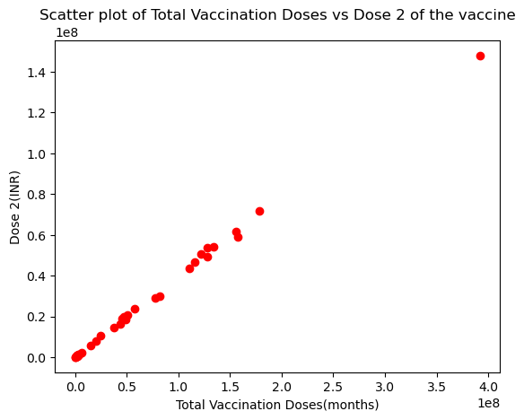

```python
plt.scatter(vaccine_backup['Total Vaccination Doses'],vaccine_backup['Dose 2'], c='red')
plt.title('Scatter plot of Total Vaccination Doses vs Dose 2 of the vaccine')
plt.xlabel('Total Vaccination Doses(months)')
plt.ylabel('Dose 2(INR)')
```

This code will generate a regression plot with 'Total Vaccination Doses' on the x-axis, 'Dose 1 12-14' on the y-axis, a regression line representing the relationship between the two variables, and asterisk markers for the data points. The plot will have a dark grid background, as specified by the sns.set(style="darkgrid") line.

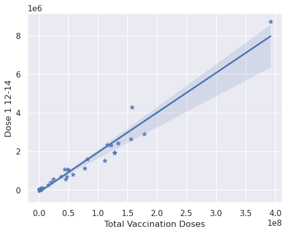

```python
sns.set(style="darkgrid")
sns.regplot(x=vaccine_backup['Total Vaccination Doses'],y=vaccine_backup['Dose 1 12-14'],fit_reg=True, marker="*")
```

This code will create an lmplot displaying 'Total Vaccination Doses' on the x-axis, 'Population' on the y-axis, with data points colored based on the values in the 'Dose 1 12-14' column. The legend will indicate the colors corresponding to each unique value in the 'Dose 1 12-14' column. No regression line will be fit to the data points due to fit_reg=False.

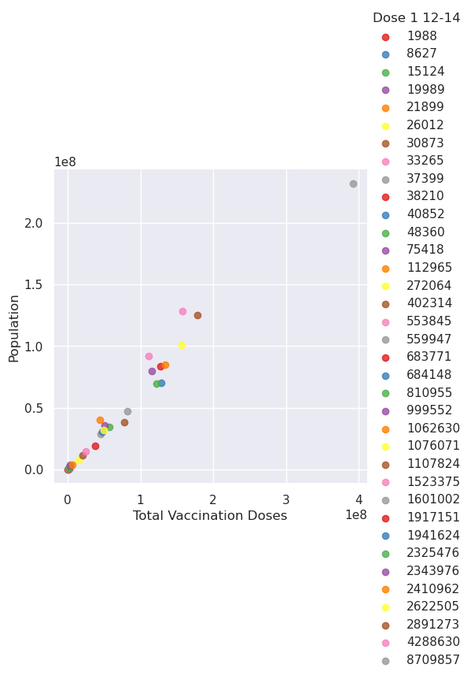

```python
sns.lmplot(x='Total Vaccination Doses',y='Population', data=vaccine_backup, fit_reg=False, hue='Dose 1 12-14', legend=True, palette='Set1')
```